# Knowledge Graph Project

Milena Atanasova

# Digital University, Theses, Publications, and Staff

## Knowledge Graph Engineering, UniTrento 2022/2023

This page describes the process and outcome of the engineering of a knowledge graph about “Digital University: Theses, Publications, and Staff”. The graph consists of a knowledge layer and a data layer. Entities are instances of the E-type classes, which have their own data properties, as well as object properties which connect them.

The project has been implemented following the iTelos methodology which provides a schema to follow implementing phase after phase and achieving intermediate and eventually final results. This is done with the aim to not only create a graph for the specific case in hand, but to also allow for potential reuse and expansion.

**1. Purpose and Domain of Interest**

The main purpose of this project as expressed by the final user is the following:

“A service which help the users to query and know about the different areas of academic and research interest being pursued at the University of Trento.”

Having in mind this informal purpose, the specific Domain of Interest (DoI) was defined as:

Academics at the University of Trento, including information mainly about research activities, between the years 2020 and 2022.

**2. Data and Knowledge resources**

For the purpose described above, the data source which seemed most authentic, convenient, and useful, was OpenDataTrentino Portal. From there, several datasets were extracted:

• [Theses](https://dati.trentino.it/dataset/tesi-di-laurea-universita-di-trento)

• [Publications](https://dati.trentino.it/dataset/pubblicazioni-universita-di-trento/resource/eb6a441e-6981-4608-ba5d-53f3116a5904)

• [Staff](https://dati.trentino.it/dataset/staff-of-the-university-of-trento)

• [Courses](https://dati.trentino.it/dataset/insegnamenti-universita-di-trento)

To supplement those sources, another small dataset was created by collecting data from the Digital University UniTn portal ([link](https://webapps.unitn.it/du/en/StrutturaAccademica)), page about the departments and some basic information about them.

Knowledge sources refer to reference schemas which have already been built and have been proven to be good for reuse, and also provide basic and specific properties. Those here are used for reference and in order to build a schema for the ontology.

• [FOAF](https://lov.linkeddata.es/dataset/lov/vocabs/foaf)

• [VIVO](https://lov.linkeddata.es/dataset/lov/vocabs/vivo)

• [Schema.org](https://schema.org/docs/full.html)

• IAO (Information Artifact Ontology)

• [DCAT 2](https://www.w3.org/TR/vocab-dcat-2/) for metadata

**3. Purpose Formalization**

Parting from the purpose and DoI, scenarios, personas, and competency questions are identified in order to help understand how the structure of the graph would look like. Those are available in the Inception sheet ([link](https://github.com/atanasova16/TrentinoDUniTPS/blob/main/Teleologies/Inception/PFSheet_DUTPS_finalversion.xlsx)).

**4. Inception**

At this phase, the data was collected, cleaned, and organized in such a way that every extracted dataset would refer to one specific entity type. This was done considering always the issue of connectivity between the dataset and keeping track of identifiers.

On the knowledge level instead, the identified entity types were given a form by creating *owl* files for each with the respective data properties. Those are afterwards reused in order to construct a single *owl* file containing all the previously identified entities.

**5. Informal Modeling**

All the entities that we identified during the previous phase from the Competency questions and modeling sheet are divided into three categories: common, core, and contextual. The division can be seen at the Entity relationship diagram, which shows how they are connected among each other.

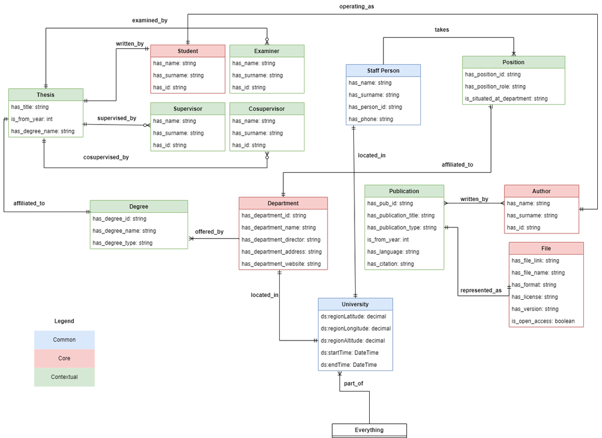

There are 12 classes (**E-types**):

• Student: a core type entity describing any university student

• Supervisor: a contextual type entity to describe a professor who helps the student to write a thesis

• Cosupervisor: a contextual type entity to describe a person who helps student to write a thesis, but is not the main one doing it.

• Examiner: a contextual type entity to describe the person who valuate the student career and his final work

• Thesis: a contextual type entity describing the thesis document

• Department: a core type entity describing a university faculty

• Degree: a contextual type entity describing any general study courses offered by university

• Staff person: a common type entity describing any human who is working in a particular place

• Position: a contextual type entity to describe the specific role a staff person takes

• Publication: a contextual type entity to describe the work of publishing followed by re- search and professors

• Author: a core type entity describing the general information about this type of staff person

• File: a core type entity describing the general information about a representation of a doc- ument

With 11 **object properties** which work as either functions or actions:

• written_by (Thesis written by Student; Publication written by Author)

• supervised_by (Thesis being supervised by a particular person)

• cosupervised_by (The Co-supervisor for a Thesis of a student)

• examined_by (who the Examiner for this Thesis is)

• affiliated_to (two respective domains and ranges: Thesis to a Degree, meaning what study

program was the thesis allowing the student to finish; Position to Department as the job place)

• offered_by (Degree program is offered by a specific Department of the university)

• takes (a Staff Person having a particular position)

• operating_as (Student who is also an Author of a publication)

• represented_as (How a Publication is digitally stored as a File)

• located_in (two domains and ranges: Department in a University; Staff Person in a Univer- sity)

• part_of (wrapping University to Everything)

The teleology is also implemented with the protégé tool and available in the repository, together with the diagram ([link](https://github.com/atanasova16/TrentinoDUniTPS/tree/main/Teleologies/Informal%20Modeling)).

**6. Formal modeling**

At this stage, an ontology composed of reference schemas e-type has been proposed, showing the hierarchy among them. The diagram can be seen in the repository [link](https://github.com/atanasova16/TrentinoDUniTPS/blob/main/Teleologies/Informal%20Modeling/ontology2.owl).

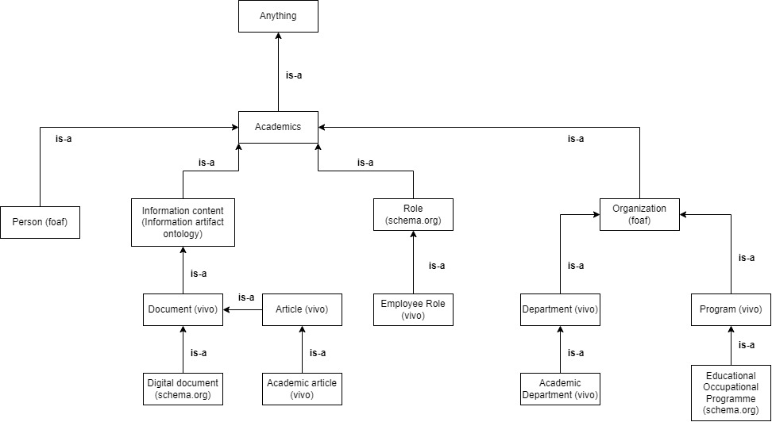

The entity types included are:

• Academic department

• Department

• Educational Occupational Program

• Program

• Employee Role

• Digital Document

• Academic Article

• Article

• Document

• Person

• Information content

• Role

• Organization

Those were chosen as a reference and as having the meaning intended.

Afterwards, by combining informal modeling output teleology with this defined ontology, the teleontology for this project was obtained. At this [link](https://github.com/atanasova16/TrentinoDUniTPS/tree/main/Teleologies/Formal%20Modeling) are the *owl* file, together with the diagram.

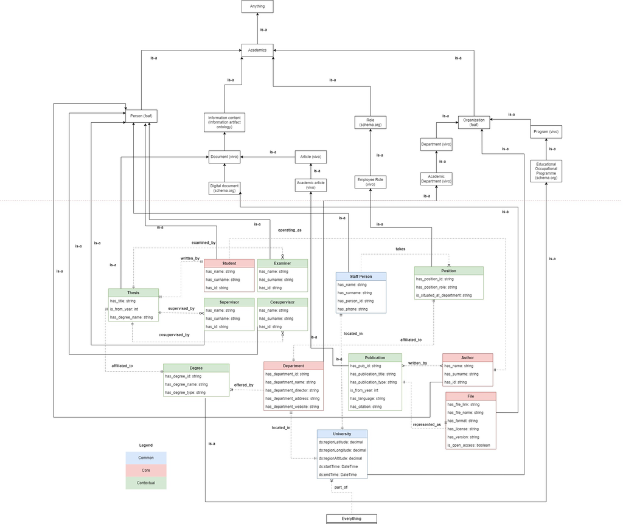

Finally, due to the issue of knowledge representation diversity due to different cultures, languages, and meanings, there is a sector concerning language annotation, where all concepts identified were given the meaning that was intended. A sheet showing these annotation problems is present [here](https://github.com/atanasova16/TrentinoDUniTPS/blob/main/Teleologies/Formal%20Modeling/TrentinoDUniTPS-4v2-changelog--2022-12-08_09:12:38.xlsx).

**7. Knowledge graph construction**

Using the Karma data linker tool, the datasets were mapped to the respective classes in order to build the final knowledge graph. The outputs are in *ttl* form in the [folder about Data integration](https://github.com/atanasova16/TrentinoDUniTPS/tree/main/Teleologies/Data%20Integration).

All these files have been put in a database using GraphDB, which allows to do some evaluation and exploration, by giving visual perspective, but also by allowing to write SPARQL queries extracting data. This can be replicated if needed by creating a new Database repository with GraphDB and importing the above-mentioned files. Several examples of queries have been shown in the report, and some of them are available in the repository.

Below, links to:

• [Final presentation](https://github.com/atanasova16/TrentinoDUniTPS/blob/main/Documentation/Digital%20University%20Theses%20Publications%20and%20Staff.pdf)

• [Full report](https://github.com/atanasova16/TrentinoDUniTPS/blob/main/Documentation/TrentinoDUniTPS-9v0-KGE_2022_Report_FinalVersion.pdf)

• [Repository on GitHub](https://github.com/atanasova16/TrentinoDUniTPS)